# Recall performance for objects inside the rooms

# 1 Visual inspection of the data

# 2 Novelty Benefits

## 2.1 Check the data

- **Is there any corrected hit rate < 0?**
- There are 4 negative value

## 2.2 Compare mean accuracy between *novel* and *familiar* rooms

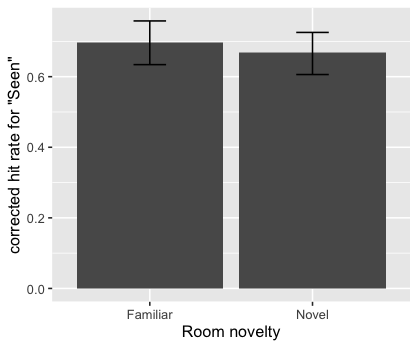

| Group | Mean | SD | N |
| --- | --- | --- | --- |
| Novel | 0.6683925 | 0.1927814 | 40 |
| Familiar | 0.6976776 | 0.1981625 | 40 |

```
    Paired t-test

data:  SAcc by Group
t = 1.5812, df = 39, p-value = 0.1219
alternative hypothesis: true difference in means is not equal to 0
95 percent confidence interval:
 -0.008177832  0.066748093
sample estimates:
mean of the differences
             0.02928513
```

## 2.3 Any difference between *Early* and *Later* object groups?

### 2.3.1 Check the data

| SubjectNo | Context | Group | CurRating | ObjOrdGrp | SHit | SFHit | SFalse | SFFalse | SAcc |
| --- | --- | --- | --- | --- | --- | --- | --- | --- | --- |
| P09 | Classroom | Familiar | 3 | Early | 0.0 | 0.6666667 | 0.05555556 | 0.2222222 | -0.05555556 |
| P11 | LivingRoom | Novel | 6 | Later | 0.0 | 0.0000000 | 0.55000000 | 0.5500000 | -0.55000000 |
| P11 | Classroom | Familiar | 5 | Later | 0.5 | 0.5000000 | 0.55000000 | 0.5500000 | -0.05000000 |
| P82 | Gym | Novel | 6 | Early | 0.0 | 1.0000000 | 0.05555556 | 0.5000000 | -0.05555556 |
| P85 | Library | Familiar | 7 | Later | 0.0 | 0.0000000 | 0.05555556 | 0.1666667 | -0.05555556 |
| P85 | StorageRoom | Familiar | 6 | Early | 0.0 | 1.0000000 | 0.05555556 | 0.1666667 | -0.05555556 |
| P85 | Bedroom | Novel | 2 | Later | 0.0 | 0.0000000 | 0.05555556 | 0.1666667 | -0.05555556 |
| P85 | LivingRoom | Familiar | 6 | Early | 0.0 | 0.6666667 | 0.05555556 | 0.1666667 | -0.05555556 |
| P86 | Classroom | Novel | 6 | Later | 0.0 | 0.0000000 | 0.16666667 | 0.4444444 | -0.16666667 |
| P86 | StorageRoom | Familiar | 3 | Later | 0.0 | 0.3333333 | 0.16666667 | 0.4444444 | -0.16666667 |

[output cut: 1 more lines]

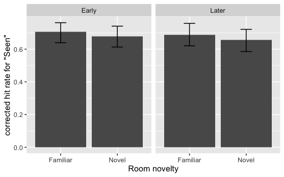

| Group | ObjOrdGrp | Mean | SD | N |
| --- | --- | --- | --- | --- |
| Novel | Early | 0.6787683 | 0.2181659 | 40 |
| Novel | Later | 0.6579349 | 0.2334047 | 40 |
| Familiar | Later | 0.6889865 | 0.2262043 | 40 |
| Familiar | Early | 0.7065461 | 0.1980664 | 40 |

|  | Effect | DFn | DFd | F | p | p<.05 | ges |
| --- | --- | --- | --- | --- | --- | --- | --- |
| 2 | Group | 1 | 39 | 2.527568468 | 0.1199473 |  | 4.589408e-03 |
| 3 | ObjOrdGrp | 1 | 39 | 0.629486933 | 0.4323444 |  | 1.959815e-03 |
| 4 | Group:ObjOrdGrp | 1 | 39 | 0.006747972 | 0.9349507 |  | 1.427798e-05 |

```
NA
```

# 3 Curiosity Enhancement

## 3.1 Check the data

### 3.1.1 Is there any corrected hit rate < 0?

#### 3.1.1.1 For the data per room

| SubjectNo | Context | Group | CurRating | RoomOrder | Duration | SFHit | SHit | SrcHit | SFFalse | SFalse | SrcFalse | SFAcc | SAcc | SrcAcc |
| --- | --- | --- | --- | --- | --- | --- | --- | --- | --- | --- | --- | --- | --- | --- |
| P86 | StorageRoom | Familiar | 3 | Second | 86.98412 | 0.5 | 0 | 0.1666667 | 0.4444444 | 0.1666667 | 0.1111111 | 0.05555556 | -0.1666667 | 0.05555556 |

#### 3.1.1.2 For the data per curiosity group

- There are 4 negative value for curiosity group (1 ~ 3 and 5 ~ 7).

#### 3.1.1.3 For the data per curiosity group (median)

- There are 4 negative value for curiosity group (median).

## 3.2 Mean accuracy of item memory as a function of curiosity rating

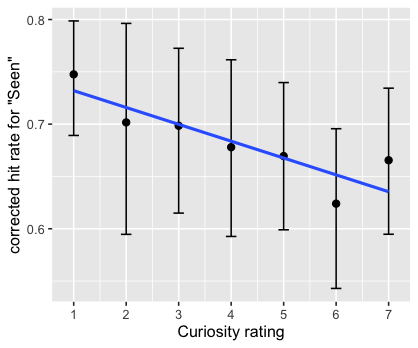

## 3.3 Testing the relationship between mean accuracy of item memory and curiosity rating

Build models with item memory accuracy as $y$ and examine effects of curiosity rating by including it into the model and then comparing the model fits.

- `baseline.rating` is the model with only an intercept, showing no change in item memory as a function of curiosity rating.
- `rating.intercept` is the model with $\small EncodingRating$ included, showing the effects of curiosity rating.
- `rating.slope` is the model allowing the slope (i.e., relationship between item memory and curiosity rating) varying across participants.

|  | Model | df | AIC | BIC | logLik | Test | L.Ratio | p-value |
| --- | --- | --- | --- | --- | --- | --- | --- | --- |
| baseline.rating | 1 | 3 | -101.8051 | -91.37573 | 53.90256 |  |  |  |
| rating.intercept | 2 | 4 | -108.7034 | -94.79758 | 58.35172 | 1 vs 2 | 8.898314 | 0.0029 |
| rating.slope | 3 | 6 | -104.6843 | -83.82556 | 58.34217 | 2 vs 3 | 0.019091 | 0.9905 |

```
Linear mixed-effects model fit by maximum likelihood
 Data: inside.hit.rate.per.room
```

|  | AIC | BIC | logLik |
| --- | --- | --- | --- |
|  | -104.6843 | -83.82556 | 58.34217 |

```
Random effects:
 Formula: ~1 + CurRating | SubjectNo
 Structure: General positive-definite, Log-Cholesky parametrization
            StdDev      Corr
(Intercept) 0.169318374 (Intr)
CurRating   0.001481275 0.044
Residual    0.159692619

Fixed effects: SAcc ~ CurRating
```

|  | Value | Std.Error | DF | t-value | p-value |
| --- | --- | --- | --- | --- | --- |
| (Intercept) | 0.7481163 | 0.03600988 | 198 | 20.775308 | 0.0000 |
| CurRating | -0.0159861 | 0.00532934 | 198 | -2.999644 | 0.0031 |

```
 Correlation:
          (Intr)
CurRating -0.598

Standardized Within-Group Residuals:
       Min         Q1        Med         Q3        Max
-2.7179957 -0.5858579  0.1236942  0.6109349  2.4403793

Number of Observations: 239
Number of Groups: 40
```

## 3.4 Check the curiosity groups

### 3.4.1 Separate the groups according to the rating

- *High*: curiosity rating > 4
- *Low*: curiosity rating < 4
- For curiosity rating = 4, discarded

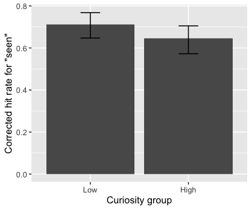

```
Linear mixed-effects model fit by maximum likelihood
 Data: inside.hit.rate.curiosity.group
```

|  | AIC | BIC | logLik |
| --- | --- | --- | --- |
|  | -65.4875 | -51.34725 | 38.74375 |

```
Random effects:
 Formula: ~1 + CurGrp | SubjectNo
 Structure: General positive-definite, Log-Cholesky parametrization
            StdDev     Corr
(Intercept) 0.20451855 (Intr)
CurGrpHigh  0.07110905 -0.27
Residual    0.05542611

Fixed effects: SAcc ~ CurGrp
```

|  | Value | Std.Error | DF | t-value | p-value |
| --- | --- | --- | --- | --- | --- |
| (Intercept) | 0.7033775 | 0.03415546 | 39 | 20.593411 | 0.0000 |
| CurGrpHigh | -0.0584634 | 0.01737650 | 37 | -3.364507 | 0.0018 |

```
 Correlation:
           (Intr)
CurGrpHigh -0.327

Standardized Within-Group Residuals:
        Min          Q1         Med          Q3         Max
-1.44334699 -0.32147525  0.05336239  0.37277305  1.31024601

Number of Observations: 78
Number of Groups: 40
```

### 3.4.2 Curiosity groups and temporal order of the objects

#### 3.4.2.1 Check the data

| SubjectNo | CurGrp | ObjOrdGrp | SFHit | SHit | SrcHit | SFFalse | SFalse | SrcFalse | SFAcc | SAcc | SrcAcc |
| --- | --- | --- | --- | --- | --- | --- | --- | --- | --- | --- | --- |
| P11 | High | Later | 0.5 | 0.5 | 0.3333333 | 0.55 | 0.55 | 0.1833333 | -0.05 | -0.05 | 0.15 |

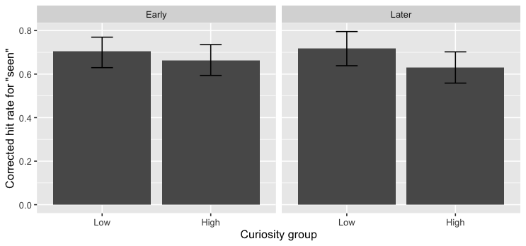

| CurGrp | ObjOrdGrp | Mean | SD | N |
| --- | --- | --- | --- | --- |
| High | Early | 0.6637683 | 0.2353545 | 40 |
| High | Later | 0.6309905 | 0.2422138 | 40 |
| Low | Later | 0.7190982 | 0.2412999 | 38 |
| NA | Later | 0.6684773 | 0.3025263 | 17 |
| Low | Early | 0.7059403 | 0.2175777 | 38 |
| NA | Early | 0.7221018 | 0.2541094 | 17 |

|  | Model | df | AIC | BIC | logLik | Test | L.Ratio | p-value |
| --- | --- | --- | --- | --- | --- | --- | --- | --- |
| baseline | 1 | 8 | -69.57425 | -45.17540 | 42.78713 |  |  |  |
| ord.model | 2 | 9 | -68.82602 | -41.37732 | 43.41301 | 1 vs 2 | 1.251769 | 0.2632 |
| cur.model | 3 | 10 | -74.48942 | -43.99086 | 47.24471 | 2 vs 3 | 7.663399 | 0.0056 |
| int.model | 4 | 11 | -73.90885 | -40.36043 | 47.95442 | 3 vs 4 | 1.419427 | 0.2335 |

```
Linear mixed-effects model fit by maximum likelihood
 Data: inside.hit.rate.item.order.curiosity[!is.na(CurGrp)]
```

|  | AIC | BIC | logLik |
| --- | --- | --- | --- |
|  | -73.90885 | -40.36043 | 47.95442 |

```
Random effects:
 Formula: ~1 + CurGrp + ObjOrdGrp | SubjectNo
 Structure: General positive-definite, Log-Cholesky parametrization
               StdDev     Corr
(Intercept)    0.18653602 (Intr) CrGrpH
CurGrpHigh     0.04089901  0.009
ObjOrdGrpLater 0.13836776 -0.006 -0.996
Residual       0.11600454

Fixed effects: SAcc ~ ObjOrdGrp + CurGrp + ObjOrdGrp:CurGrp
```

|  | Value | Std.Error | DF | t-value | p-value |
| --- | --- | --- | --- | --- | --- |
| (Intercept) | 0.6988053 | 0.03555706 | 113 | 19.653065 | 0.0000 |
| ObjOrdGrpLater | 0.0119031 | 0.03511542 | 113 | 0.338970 | 0.7353 |
| CurGrpHigh | -0.0350370 | 0.02756300 | 113 | -1.271160 | 0.2063 |
| ObjOrdGrpLater:CurGrpHigh | -0.0446809 | 0.03784726 | 113 | -1.180558 | 0.2403 |

```
 Correlation:
                          (Intr) ObjOGL CrGrpH
ObjOrdGrpLater            -0.296
CurGrpHigh                -0.377  0.229
ObjOrdGrpLater:CurGrpHigh  0.272 -0.558 -0.682

Standardized Within-Group Residuals:
        Min          Q1         Med          Q3         Max
-2.87947548 -0.42302508  0.03536498  0.52889319  2.20842054

Number of Observations: 156
Number of Groups: 40
```

#### 3.4.2.2 *Post hoc*

```
     Simultaneous Tests for General Linear Hypotheses

Fit: lme.formula(fixed = SAcc ~ ObjOrdGrp + CurGrp + ObjOrdGrp:CurGrp,
    data = inside.hit.rate.item.order.curiosity[!is.na(CurGrp)],
    random = ~1 + CurGrp + ObjOrdGrp | SubjectNo, method = "ML",
    na.action = na.exclude, control = list(msMaxIter = 500, opt = "optim",
        msVerbose = FALSE))

Linear Hypotheses:
                         Estimate Std. Error z value Pr(>|z|)
Early: High vs. Low == 0 -0.03504    0.02721  -1.288   0.1978
Late:  High vs. Low == 0 -0.07972    0.02738  -2.911   0.0036 **
---
Signif. codes:  0 ‘***’ 0.001 ‘**’ 0.01 ‘*’ 0.05 ‘.’ 0.1 ‘ ’ 1
(Adjusted p values reported -- none method)
```

### 3.4.3 Separate the groups according to the median rating of each participant

- *High*: curiosity rating > median of the participant
- *Low*: curiosity rating < median of the participant

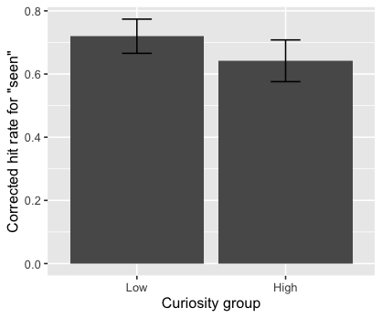

```
Linear mixed-effects model fit by maximum likelihood
 Data: inside.hit.rate.curiosity.group.median
```

|  | AIC | BIC | logLik |
| --- | --- | --- | --- |
|  | -84.52661 | -70.30992 | 48.2633 |

```
Random effects:
 Formula: ~1 + CurGrp | SubjectNo
 Structure: General positive-definite, Log-Cholesky parametrization
            StdDev     Corr
(Intercept) 0.17003266 (Intr)
CurGrpHigh  0.06803204 0.273
Residual    0.04878618

Fixed effects: SAcc ~ CurGrp
```

|  | Value | Std.Error | DF | t-value | p-value |
| --- | --- | --- | --- | --- | --- |
| (Intercept) | 0.7204349 | 0.02833018 | 39 | 25.429949 | 0 |
| CurGrpHigh | -0.0787009 | 0.01571534 | 38 | -5.007903 | 0 |

```
 Correlation:
           (Intr)
CurGrpHigh 0.045

Standardized Within-Group Residuals:
        Min          Q1         Med          Q3         Max
-1.19772342 -0.33024646  0.06743736  0.39750150  1.15924707

Number of Observations: 79
Number of Groups: 40
```

#### 3.4.3.1 Curiosity groups and temporal order of the objects

##### 3.4.3.1.1 Check the data

| SubjectNo | CurGrpMedian | ObjOrdGrp | SFHit | SHit | SrcHit | SFFalse | SFalse | SrcFalse | SFAcc | SAcc | SrcAcc |
| --- | --- | --- | --- | --- | --- | --- | --- | --- | --- | --- | --- |
| P11 | High | Later | 0.5 | 0.5 | 0.3333333 | 0.55 | 0.55 | 0.1833333 | -0.05 | -0.05 | 0.15 |

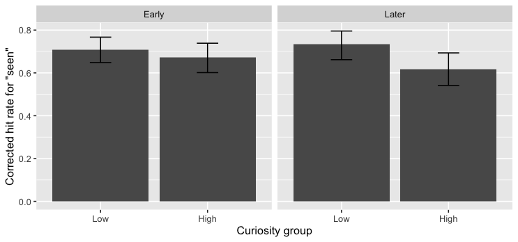

| CurGrp | ObjOrdGrp | Mean | SD | N |
| --- | --- | --- | --- | --- |
| High | Early | 0.6715999 | 0.2315399 | 39 |
| High | Later | 0.6166142 | 0.2393254 | 39 |
| Low | Later | 0.7335302 | 0.2176017 | 40 |
| Low | Early | 0.7079349 | 0.1929949 | 40 |
| NA | Early | 0.6750000 | 0.1028153 | 5 |
| NA | Later | 0.5148990 | 0.4096054 | 5 |

|  | Model | df | AIC | BIC | logLik | Test | L.Ratio | p-value |
| --- | --- | --- | --- | --- | --- | --- | --- | --- |
| baseline | 1 | 8 | -82.86410 | -58.36334 | 49.43205 |  |  |  |
| ord.model | 2 | 9 | -81.38195 | -53.81860 | 49.69098 | 1 vs 2 | 0.517850 | 0.4718 |
| cur.model | 3 | 10 | -92.72765 | -62.10170 | 56.36382 | 2 vs 3 | 13.345694 | 0.0003 |
| int.model | 4 | 11 | -95.21279 | -61.52424 | 58.60639 | 3 vs 4 | 4.485144 | 0.0342 |

```
Linear mixed-effects model fit by maximum likelihood
 Data: inside.hit.rate.item.order.curiosity.median[!is.na(CurGrp)]
```

|  | AIC | BIC | logLik |
| --- | --- | --- | --- |
|  | -95.21279 | -61.52424 | 58.60639 |

```
Random effects:
 Formula: ~1 + CurGrp + ObjOrdGrp | SubjectNo
 Structure: General positive-definite, Log-Cholesky parametrization
               StdDev     Corr
(Intercept)    0.15362742 (Intr) CrGrpH
CurGrpHigh     0.03645412  0.910
ObjOrdGrpLater 0.09843214  0.007 -0.379
Residual       0.11675666

Fixed effects: SAcc ~ ObjOrdGrp + CurGrp + ObjOrdGrp:CurGrp
```

|  | Value | Std.Error | DF | t-value | p-value |
| --- | --- | --- | --- | --- | --- |
| (Intercept) | 0.7079349 | 0.03090332 | 115 | 22.908055 | 0.0000 |
| ObjOrdGrpLater | 0.0255952 | 0.03078674 | 115 | 0.831372 | 0.4075 |
| CurGrpHigh | -0.0371597 | 0.02737127 | 115 | -1.357617 | 0.1772 |
| ObjOrdGrpLater:CurGrpHigh | -0.0797232 | 0.03769590 | 115 | -2.114905 | 0.0366 |

```
 Correlation:
                          (Intr) ObjOGL CrGrpH
ObjOrdGrpLater            -0.365
CurGrpHigh                -0.259  0.374
ObjOrdGrpLater:CurGrpHigh  0.300 -0.603 -0.689

Standardized Within-Group Residuals:
       Min         Q1        Med         Q3        Max
-2.0193030 -0.4810167  0.1106042  0.5694013  2.2852974

Number of Observations: 158
Number of Groups: 40
```

# 4 **Novelty** or **Curiosity**?

## 4.1 For Curiosity group splitted by score (*Low*: 1 ~ 3; *High*: 5 ~ 7)

### 4.1.1 Curiosity first, novelty next

|  | Model | df | AIC | BIC | logLik | Test | L.Ratio | p-value |
| --- | --- | --- | --- | --- | --- | --- | --- | --- |
| base.model | 1 | 8 | -82.69518 | -55.69296 | 49.34759 |  |  |  |
| cur.scr.model | 2 | 9 | -87.28029 | -56.90278 | 52.64015 | 1 vs 2 | 6.585107 | 0.0103 |
| nov.scr.model | 3 | 10 | -85.38728 | -51.63449 | 52.69364 | 2 vs 3 | 0.106987 | 0.7436 |

```
Linear mixed-effects model fit by maximum likelihood
 Data: inside.hit.rate.per.room[!is.na(CurGrp)]
```

|  | AIC | BIC | logLik |
| --- | --- | --- | --- |
|  | -85.38728 | -51.63449 | 52.69364 |

```
Random effects:
 Formula: ~1 + CurGrp + Group | SubjectNo
 Structure: General positive-definite, Log-Cholesky parametrization
            StdDev       Corr
(Intercept) 0.1848105174 (Intr) CrGrpL
CurGrpLow   0.0004444148 -0.001
GroupNovel  0.0003956550 -0.004  0.004
Residual    0.1554823524

Fixed effects: SAcc ~ Group + CurGrp
```

|  | Value | Std.Error | DF | t-value | p-value |
| --- | --- | --- | --- | --- | --- |
| (Intercept) | 0.6422252 | 0.03754832 | 174 | 17.103967 | 0.0000 |
| GroupNovel | 0.0078913 | 0.02429136 | 174 | 0.324861 | 0.7457 |
| CurGrpLow | 0.0641539 | 0.02498164 | 174 | 2.568040 | 0.0111 |

```
 Correlation:
           (Intr) GrpNvl
GroupNovel -0.474
CurGrpLow  -0.469  0.469

Standardized Within-Group Residuals:
       Min         Q1        Med         Q3        Max
-2.8636508 -0.5507424  0.1540741  0.6106102  1.9596141

Number of Observations: 216
Number of Groups: 40
```

### 4.1.2 Novelty first, curiosity next

|  | Model | df | AIC | BIC | logLik | Test | L.Ratio | p-value |
| --- | --- | --- | --- | --- | --- | --- | --- | --- |
| base.model | 1 | 8 | -82.69518 | -55.69296 | 49.34759 |  |  |  |
| nov.scr.model | 2 | 9 | -82.04726 | -51.66976 | 50.02363 | 1 vs 2 | 1.352081 | 0.2449 |
| cur.scr.model | 3 | 10 | -85.38728 | -51.63449 | 52.69364 | 2 vs 3 | 5.340013 | 0.0208 |

```
Linear mixed-effects model fit by maximum likelihood
 Data: inside.hit.rate.per.room[!is.na(CurGrp)]
```

|  | AIC | BIC | logLik |
| --- | --- | --- | --- |
|  | -82.04726 | -51.66976 | 50.02363 |

```
Random effects:
 Formula: ~1 + CurGrp + Group | SubjectNo
 Structure: General positive-definite, Log-Cholesky parametrization
            StdDev     Corr
(Intercept) 0.20975302 (Intr) CrGrpL
CurGrpLow   0.02230732 -0.893
GroupNovel  0.03395224 -0.912  0.960
Residual    0.15746659

Fixed effects: SAcc ~ Group
```

|  | Value | Std.Error | DF | t-value | p-value |
| --- | --- | --- | --- | --- | --- |
| (Intercept) | 0.6974243 | 0.03454073 | 175 | 20.191361 | 0.0000 |
| GroupNovel | -0.0253533 | 0.02208039 | 175 | -1.148226 | 0.2524 |

```
 Correlation:
           (Intr)
GroupNovel -0.45

Standardized Within-Group Residuals:
       Min         Q1        Med         Q3        Max
-2.6979209 -0.6155156  0.1564843  0.5765898  2.0937184

Number of Observations: 216
Number of Groups: 40
```

## 4.2 For Curiosity group splitted by individual medians

### 4.2.1 Curiosity first, novelty next

|  | Model | df | AIC | BIC | logLik | Test | L.Ratio | p-value |
| --- | --- | --- | --- | --- | --- | --- | --- | --- |
| base.model | 1 | 8 | -94.75352 | -67.38924 | 55.37676 |  |  |  |
| cur.md.model | 2 | 9 | -105.03689 | -74.25208 | 61.51845 | 1 vs 2 | 12.283371 | 0.0005 |
| nov.md.model | 3 | 10 | -103.01524 | -68.80989 | 61.50762 | 2 vs 3 | 0.021654 | 0.8830 |

```
Linear mixed-effects model fit by maximum likelihood
 Data: inside.hit.rate.per.room[!is.na(CurGrpMedian)]
```

|  | AIC | BIC | logLik |
| --- | --- | --- | --- |
|  | -103.0152 | -68.80989 | 61.50762 |

```
Random effects:
 Formula: ~1 + CurGrpMedian + Group | SubjectNo
 Structure: General positive-definite, Log-Cholesky parametrization
                StdDev       Corr
(Intercept)     0.1877377119 (Intr) CrGrML
CurGrpMedianLow 0.0300819252 -0.970
GroupNovel      0.0002741351 -0.004  0.004
Residual        0.1531058275

Fixed effects: SAcc ~ Group + CurGrpMedian
```

|  | Value | Std.Error | DF | t-value | p-value |
| --- | --- | --- | --- | --- | --- |
| (Intercept) | 0.6440000 | 0.03764923 | 184 | 17.105263 | 0.0000 |
| GroupNovel | -0.0013861 | 0.02359142 | 184 | -0.058754 | 0.9532 |
| CurGrpMedianLow | 0.0779496 | 0.02402782 | 184 | 3.244140 | 0.0014 |

```
 Correlation:
                (Intr) GrpNvl
GroupNovel      -0.461
CurGrpMedianLow -0.613  0.474

Standardized Within-Group Residuals:
       Min         Q1        Med         Q3        Max
-2.9485878 -0.6587511  0.1264151  0.6330042  2.0166189

Number of Observations: 226
Number of Groups: 40
```

### 4.2.2 Novelty first, curiosity next

|  | Model | df | AIC | BIC | logLik | Test | L.Ratio | p-value |
| --- | --- | --- | --- | --- | --- | --- | --- | --- |
| base.model | 1 | 8 | -94.75352 | -67.38924 | 55.37676 |  |  |  |
| nov.md.model | 2 | 9 | -97.40828 | -66.62346 | 57.70414 | 1 vs 2 | 4.654756 | 0.0310 |
| cur.md.model | 3 | 10 | -103.01524 | -68.80989 | 61.50762 | 2 vs 3 | 7.606961 | 0.0058 |

```
Linear mixed-effects model fit by maximum likelihood
 Data: inside.hit.rate.per.room[!is.na(CurGrpMedian)]
```

|  | AIC | BIC | logLik |
| --- | --- | --- | --- |
|  | -97.40828 | -66.62346 | 57.70414 |

```
Random effects:
 Formula: ~1 + CurGrpMedian + Group | SubjectNo
 Structure: General positive-definite, Log-Cholesky parametrization
                StdDev     Corr
(Intercept)     0.22389198 (Intr) CrGrML
CurGrpMedianLow 0.06288360 -0.981
GroupNovel      0.03922534 -0.961  0.978
Residual        0.15555689

Fixed effects: SAcc ~ Group
```

|  | Value | Std.Error | DF | t-value | p-value |
| --- | --- | --- | --- | --- | --- |
| (Intercept) | 0.7314537 | 0.03007420 | 185 | 24.321630 | 0.0000 |
| GroupNovel | -0.0481855 | 0.02115414 | 185 | -2.277826 | 0.0239 |

```
 Correlation:
           (Intr)
GroupNovel -0.38

Standardized Within-Group Residuals:
       Min         Q1        Med         Q3        Max
-2.7774897 -0.5959973  0.1271463  0.5998362  1.9627796

Number of Observations: 226
Number of Groups: 40
```